# Lab 1.4: Data Representations

## 4.4 *GenomicAlignments* (Aligned reads)

Classes – GenomicRanges-like behaivor

- GAlignments, GAlignmentPairs, GAlignmentsList

Methods

- `readGAlignments()`, `readGAlignmentsList()`
  - Easy to restrict input, iterate in chunks
- `summarizeOverlaps()`

**Exercises**

1. Find reads supporting the junction identified above, at position 19653707 + 66M = 19653773 of chromosome 14

   ```r
   library(GenomicRanges)
   library(GenomicAlignments)
   library(Rsamtools)

   ## our 'region of interest'
   roi <- GRanges("chr14", IRanges(19653773, width=1))
   ## sample data
   library('RNAseqData.HNRNPC.bam.chr14')
   bf <- BamFile(RNAseqData.HNRNPC.bam.chr14_BAMFILES[[1]], asMates=TRUE)
   ## alignments, junctions, overlapping our roi
   paln <- readGAlignmentsList(bf)
   j <- summarizeJunctions(paln, with.revmap=TRUE)
   j_overlap <- j[j %over% roi]

   ## supporting reads
   paln[j_overlap$revmap[[1]]]
   ```

   ```
   ## GAlignmentsList object of length 8:
   ## [[1]]
   ## GAlignments object with 2 alignments and 0 metadata columns:
   ##       seqnames strand       cigar    qwidth     start       end     width
   ##          <Rle>  <Rle> <character> <integer> <integer> <integer> <integer>
   ##   [1]    chr14      -   66M120N6M        72  19653707  19653898       192
   ##   [2]    chr14      +  7M1270N65M        72  19652348  19653689      1342
   ##           njunc
   ##       <integer>
   ##   [1]         1
   ##   [2]         1
   ##   -------
   ##   seqinfo: 93 sequences from an unspecified genome
   ##
   ## [[2]]
   ## GAlignments object with 2 alignments and 0 metadata columns:
   ##       seqnames strand       cigar    qwidth     start       end     width
   ##          <Rle>  <Rle> <character> <integer> <integer> <integer> <integer>
   ##   [1]    chr14      -   66M120N6M        72  19653707  19653898       192
   ##   [2]    chr14      +         72M        72  19653686  19653757        72
   ##           njunc
   ##       <integer>
   ##   [1]         1
   ##   [2]         0
   ##   -------
   ##   seqinfo: 93 sequences from an unspecified genome
   ##
   ## [[3]]
   ## GAlignments object with 2 alignments and 0 metadata columns:
   ##       seqnames strand       cigar    qwidth     start       end     width
   ##          <Rle>  <Rle> <character> <integer> <integer> <integer> <integer>
   ##   [1]    chr14      +         72M        72  19653675  19653746        72
   ##   [2]    chr14      -   65M120N7M        72  19653708  19653899       192
   ##           njunc
   ##       <integer>
   ##   [1]         0
   ##   [2]         1
   ##   -------
   ##   seqinfo: 93 sequences from an unspecified genome
   ##
   ## ...
   ## <5 more elements>
   ```

## 4.5 *VariantAnnotation* (Called variants)

Classes – GenomicRanges-like behavior

- VCF – ‘wide’
- VRanges – ‘tall’

Functions and methods

- I/O and filtering: `readVcf()`, `readGeno()`, `readInfo()`, `readGT()`, `writeVcf()`, `filterVcf()`
- Annotation: `locateVariants()` (variants overlapping ranges), `predictCoding()`, `summarizeVariants()`
- SNPs: `genotypeToSnpMatrix()`, `snpSummary()`

**Exerises**

1. Read variants from a VCF file, and annotate with respect to a known gene model

   ```r
   ## input variants
   library(VariantAnnotation)
   fl <- system.file("extdata", "chr22.vcf.gz", package="VariantAnnotation")
   vcf <- readVcf(fl, "hg19")
   seqlevels(vcf) <- "chr22"
   ## known gene model
   library(TxDb.Hsapiens.UCSC.hg19.knownGene)
   coding <- locateVariants(rowRanges(vcf),
       TxDb.Hsapiens.UCSC.hg19.knownGene,
       CodingVariants())
   head(coding)
   ```

   ```
   ## GRanges object with 6 ranges and 9 metadata columns:
   ##                   seqnames    ranges strand | LOCATION  LOCSTART    LOCEND
   ##                      <Rle> <IRanges>  <Rle> | <factor> <integer> <integer>
   ##       rs114335781    chr22  50301422      - |   coding       939       939
   ##         rs8135963    chr22  50301476      - |   coding       885       885
   ##   22:50301488_C/T    chr22  50301488      - |   coding       873       873
   ##   22:50301494_G/A    chr22  50301494      - |   coding       867       867
   ##   22:50301584_C/T    chr22  50301584      - |   coding       777       777
   ##       rs114264124    chr22  50302962      - |   coding       698       698
   ##                     QUERYID        TXID         CDSID      GENEID
   ##                   <integer> <character> <IntegerList> <character>
   ##       rs114335781        24       75253        218562       79087
   ##         rs8135963        25       75253        218562       79087
   ##   22:50301488_C/T        26       75253        218562       79087
   ##   22:50301494_G/A        27       75253        218562       79087
   ##   22:50301584_C/T        28       75253        218562       79087
   ##       rs114264124        57       75253        218563       79087
   ##                         PRECEDEID        FOLLOWID
   ##                   <CharacterList> <CharacterList>
   ##       rs114335781
   ##         rs8135963
   ##   22:50301488_C/T
   ##   22:50301494_G/A
   ##   22:50301584_C/T
   ##       rs114264124
   ##   -------
   ##   seqinfo: 1 sequence from an unspecified genome; no seqlengths
   ```

Related packages

- ensemblVEP
  - Forward variants to Ensembl Variant Effect Predictor
- VariantTools, h5vc
  - Call variants

Reference

- Obenchain, V, Lawrence, M, Carey, V, Gogarten, S, Shannon, P, and Morgan, M. VariantAnnotation: a Bioconductor package for exploration and annotation of genetic variants. Bioinformatics, first published online March 28, 2014 [doi:10.1093/bioinformatics/btu168](http://bioinformatics.oxfordjournals.org/content/early/2014/04/21/bioinformatics.btu168)

## 4.6 *rtracklayer* (Genome annotations)

- Import BED, GTF, WIG, etc
- Export GRanges to BED, GTF, WIG, …
- Access UCSC genome browser

# 5 Extended exercises

## 5.1 Summarize overlaps

The goal is to count the number of reads overlapping exons grouped into genes. This type of count data is the basic input for RNASeq differential expression analysis, e.g., through DESeq2 and edgeR.

1. Identify the regions of interest. We use a ‘TxDb’ package with gene models already defined; the genome (hg19) is determined by the genome used for read alignment in the sample BAM files.

   ```r
   library(TxDb.Hsapiens.UCSC.hg19.knownGene)
   exByGn <- exonsBy(TxDb.Hsapiens.UCSC.hg19.knownGene, "gene")
   ## only chromosome 14
   seqlevels(exByGn, pruning.mode="coarse") = "chr14"
   ```

2. Identify the sample BAM files.

   ```r
   library(RNAseqData.HNRNPC.bam.chr14)
   length(RNAseqData.HNRNPC.bam.chr14_BAMFILES)
   ```

   ```
   ## [1] 8
   ```

3. Summarize overlaps, optionally in parallel

   ```r
   ## next 2 lines optional; non-Windows
   library(BiocParallel)
   register(MulticoreParam(workers=parallel::detectCores()))
   olaps <- summarizeOverlaps(exByGn, RNAseqData.HNRNPC.bam.chr14_BAMFILES)
   ```

4. Explore our handiwork, e.g., library sizes (column sums), relationship between gene length and number of mapped reads, etc.

   ```r
   olaps
   ```

   ```
   ## class: RangedSummarizedExperiment
   ## dim: 779 8
   ## metadata(0):
   ## assays(1): counts
   ## rownames(779): 10001 100113389 ... 9950 9985
   ## rowData names(0):
   ## colnames(8): ERR127306 ERR127307 ... ERR127304 ERR127305
   ## colData names(0):
   ```

   ```r
   head(assay(olaps))
   ```

   ```
   ##           ERR127306 ERR127307 ERR127308 ERR127309 ERR127302 ERR127303 ERR127304
   ## 10001           103       139       109       125       152       168       181
   ## 100113389         0         0         0         0         0         0         0
   ## 100113391         0         0         0         0         0         0         0
   ## 100124539         0         0         0         0         0         0         0
   ## 100126297         0         0         0         0         0         0         0
   ## 100126308         0         0         0         0         0         0         0
   ##           ERR127305
   ## 10001           150
   ## 100113389         0
   ## 100113391         0
   ## 100124539         0
   ## 100126297         0
   ## 100126308         0
   ```

   ```r
   colSums(assay(olaps))                # library sizes
   ```

   ```
   ## ERR127306 ERR127307 ERR127308 ERR127309 ERR127302 ERR127303 ERR127304 ERR127305
   ##    340646    373268    371639    331518    313800    331135    331606    329647
   ```

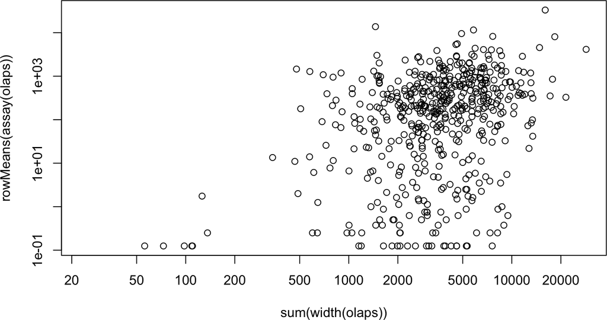

   ```r
   plot(sum(width(olaps)), rowMeans(assay(olaps)), log="xy")
   ```

5. As an advanced exercise, investigate the relationship between GC content and read count

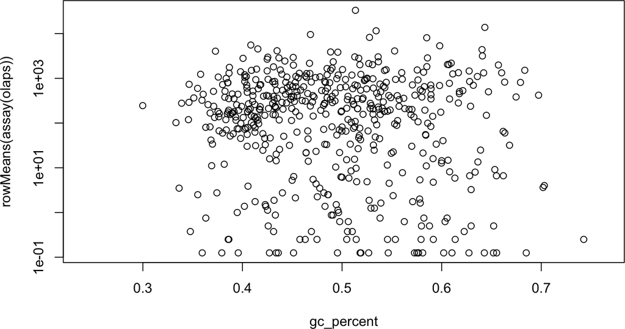

   ```r
   library(BSgenome.Hsapiens.UCSC.hg19)
   sequences <- getSeq(BSgenome.Hsapiens.UCSC.hg19, rowRanges(olaps))
   gcPerExon <- letterFrequency(unlist(sequences), "GC")
   gc <- relist(as.vector(gcPerExon), sequences)
   gc_percent <- sum(gc) / sum(width(olaps))
   plot(gc_percent, rowMeans(assay(olaps)), log="y")
   ```

# 6 End matter

## 6.2 Acknowledgements

Research reported in this tutorial was supported by the National Human Genome Research Institute and the National Cancer Institute of the National Institutes of Health under award numbers U24HG004059 (Bioconductor), U24HG010263 (AnVIL) and U24CA180996 (ITCR).